# Task 3: US Birth Data

Lucas Stark

16 10 2019

## Data Import

This research is based around weight variables of US born babies. The data was imported from [Centers for Disease Control and Prevention](https://www.cdc.gov/nchs/data_access/vitalstatsonline.htm) in form of two datasets from the years 2017 and 2018.

The data was cleaned so that only four variables for this analysis were in the dataset. You can see the structure of the dataset here:

| sex | weight | month | year |
| --- | --- | --- | --- |
| F | 3653 | 1 | 2017 |
| M | 2987 | 1 | 2017 |
| M | 3445 | 1 | 2017 |
| M | 3645 | 1 | 2017 |
| F | 860 | 1 | 2017 |
| F | 2875 | 1 | 2017 |

# Male-Female Ratio

*What is the proportion of boys to girls? Has it changed between 2017 and 2018?*

The male-to-female ration in 2017 is 1.05. In 2018 it is 1.05. So for both years, the ratio is about the same and slightly more boys get born than girls.

# Birth Weight

*What is the average birth weight in grams?*

It is 3261.89 grams.

*Did the boys differ from girls in 2018?*

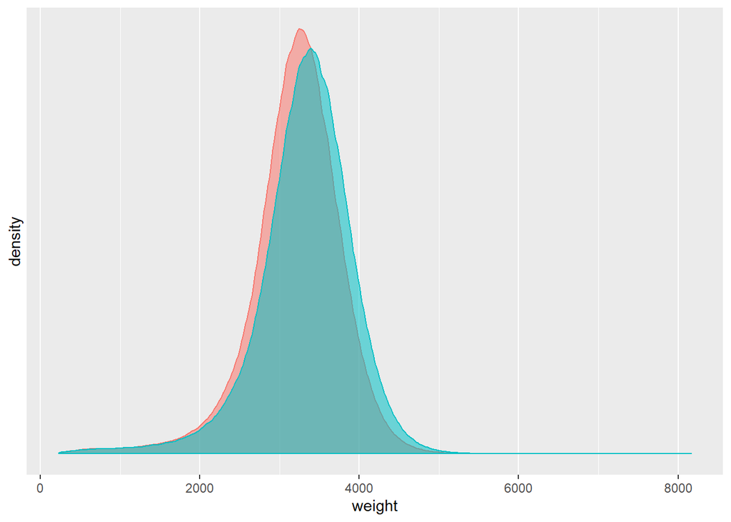

In the graphic above you can see two density plots. The red one represents the weight of the girls and the blue one the weight of the boys. You can see that boys have a slighty higher weight in 2018 than girls.

*Does the average birth weight vary by month and year?*

| year | month | avg_w |
| --- | --- | --- |
| 2017 | 1 | 3252.256 |
| 2017 | 2 | 3260.639 |
| 2017 | 3 | 3262.990 |
| 2017 | 4 | 3266.531 |
| 2017 | 5 | 3267.867 |
| 2017 | 6 | 3264.266 |
| 2017 | 7 | 3263.729 |
| 2017 | 8 | 3265.932 |
| 2017 | 9 | 3268.226 |
| 2017 | 10 | 3261.624 |
| 2017 | 11 | 3259.406 |
| 2017 | 12 | 3251.082 |
| 2018 | 1 | 3253.882 |
| 2018 | 2 | 3262.313 |
| 2018 | 3 | 3265.336 |
| 2018 | 4 | 3268.617 |
| 2018 | 5 | 3268.276 |
| 2018 | 6 | 3266.514 |
| 2018 | 7 | 3263.652 |
| 2018 | 8 | 3267.598 |
| 2018 | 9 | 3262.188 |
| 2018 | 10 | 3256.551 |
| 2018 | 11 | 3254.675 |
| 2018 | 12 | 3249.713 |

No, it doesn’t really change. It varies between 3249.71 and 3268.62 grams.